# RepData_PeerAssessment1

JJW

8/6/2020

```r
library(dplyr)
```

```r
library(tidyr)
library(ggplot2)
library(stats)
library(xtable)
```

## Loading and preprocessing the data

```r
unzip("activity.zip")
data <- read.csv("activity.csv")
## formatting date variable
data$date <- as.Date(data$date)
```

## Mean total number of steps per day

Group the data by date and sum the number of steps on each date.

```r
data_bydate <- data  %>%
    group_by(date)%>%
    summarise_at(vars(steps),list(totalsteps = sum))
```

Calculate the mean and median total of number of steps per day.

```r
avg <- summarise(data_bydate, mean_steps = mean(totalsteps,
      na.rm = TRUE), median_steps = median(totalsteps, na.rm = TRUE))

print(xtable(avg), type = "html")
```

|  | mean_steps | median_steps |
| --- | --- | --- |
| 1 | 10766.19 | 10765 |

Plot a histogram of total number of steps per day.

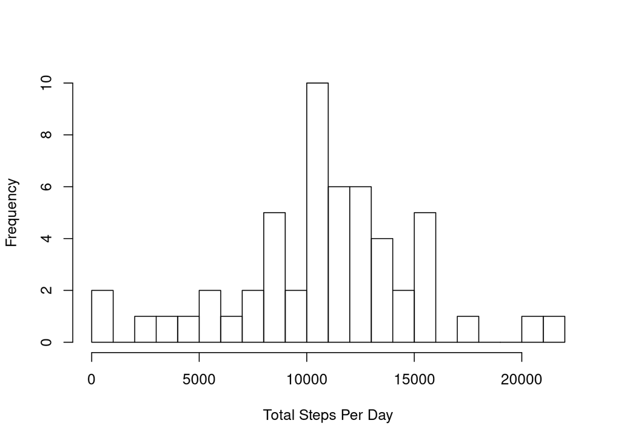

```r
hist(data_bydate$totalsteps, breaks = 20, main= NULL,
     xlab = "Total Steps Per Day" )
```

## Average daily activity pattern

Group the data by time interval and average the number of steps across all days.

```r
data_byinterval <- na.omit(data)  %>%
    group_by(interval)%>%
    summarise_at(vars(steps),list(meansteps = mean))
```

Plot average number of steps in interval.

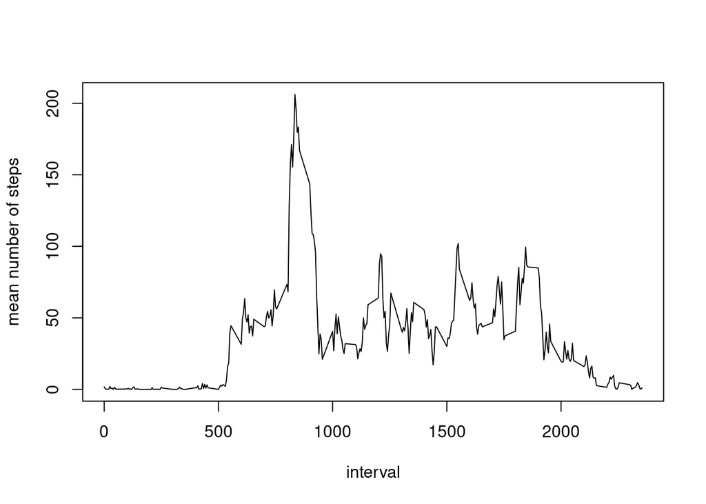

```r
with(data_byinterval, plot(x = interval, y = meansteps,
     type = "l", ylab = "mean number of steps", main = NULL))
```

Determine which interval has the highest average number of steps.

```r
max <- top_n(data_byinterval, 1, meansteps)
print(xtable(max), type = "html")
```

|  | interval | meansteps |
| --- | --- | --- |
| 1 | 835 | 206.17 |

## Impute missing values

Calculate total number of observations with missing values.

```r
NAs <- is.na(data)
sum(NAs)
```

```
## [1] 2304
```

The strategy for imputing the missing values will be to use the mean number of steps for the five minute interval across all other days.

```r
library(expss)
n = length(data$steps)
mat = matrix(rep(0,n*3),ncol = 3)
data_imputed = data.frame(mat)

for (i in 1:n){
    if(is.na(data[i,1])){
      na = vlookup(data[i,3], data_byinterval, 2, 1)
      data_imputed[i,1] = na
      data_imputed[i,3] = data[i,3]
    }else{
      data_imputed[i,1] = data[i,1]
      data_imputed[i,3] = data[i,3]
    }
}

colnames(data_imputed) <- colnames(data)
data_imputed$date <- data$date

detach("package:expss", unload=TRUE)
```

### Mean total number of steps per day (imputed data)

Group the data by date and sum the number of steps on each date.

```r
datai_bydate <- data_imputed  %>%
    group_by(date)%>%
    summarise_at(vars(steps),list(totalsteps = sum))
```

Calculate the mean and median total of number of steps per day, and compare to orginal data.

```r
avgi <- summarise(datai_bydate, mean_steps = mean(totalsteps),
          median_steps = median(totalsteps))
avgi <- as.data.frame(avgi)
rownames(avgi) = "imputed data"
avgo <- as.data.frame(avg)
rownames(avgo) = "original data"
avgt <- bind_rows(avgi, avgo)
print(xtable(avgt), type = "html")
```

|  | mean_steps | median_steps |
| --- | --- | --- |
| imputed data | 10766.19 | 10766.19 |
| original data | 10766.19 | 10765.00 |

Compared to the orignal data, the data set with imputed observations has the same mean and a slightly higher median.

Plot a histogram of total number of steps per day, and compare to original data.

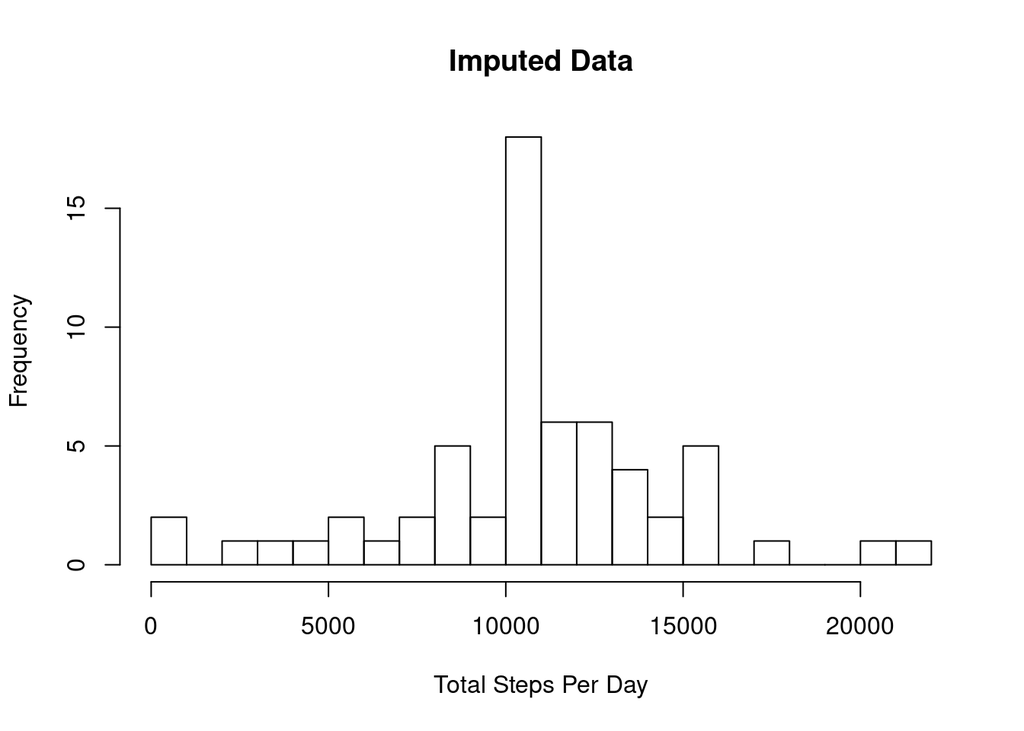

```r
hist(datai_bydate$totalsteps, breaks = 20, main= "Imputed Data",
     xlab = "Total Steps Per Day" )
```

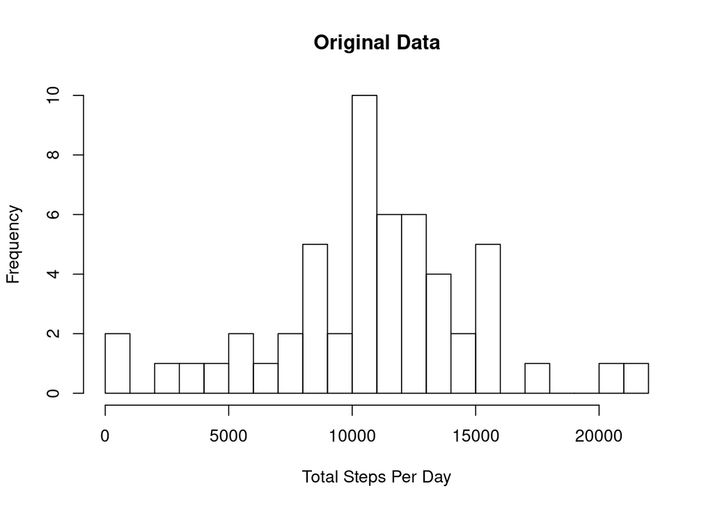

```r
hist(data_bydate$totalsteps, breaks = 20, main= "Original Data",
     xlab = "Total Steps Per Day" )
```

The overall shape of the histograms of the two datasets did not change significantly, except that there are now more observations around the average.

## Activity patterns between weekdays and weekends

```r
data_imputed_wkd <- data_imputed %>%
    mutate(day = ifelse(weekdays(data_imputed$date) == "Saturday" |
                          weekdays(data_imputed$date) == "Saturday",
                        "weekend", "weekday"))

data_imputed_wkd$day <- as.factor(data_imputed_wkd$day)
```

Group the data by day and time interval and average the number of steps across all days.

```r
data_byintervalwkd <- data_imputed_wkd  %>%
    group_by(day) %>%
    group_by(interval, .add = TRUE)%>%
    summarise_at(vars(steps),list(meansteps = mean))
```

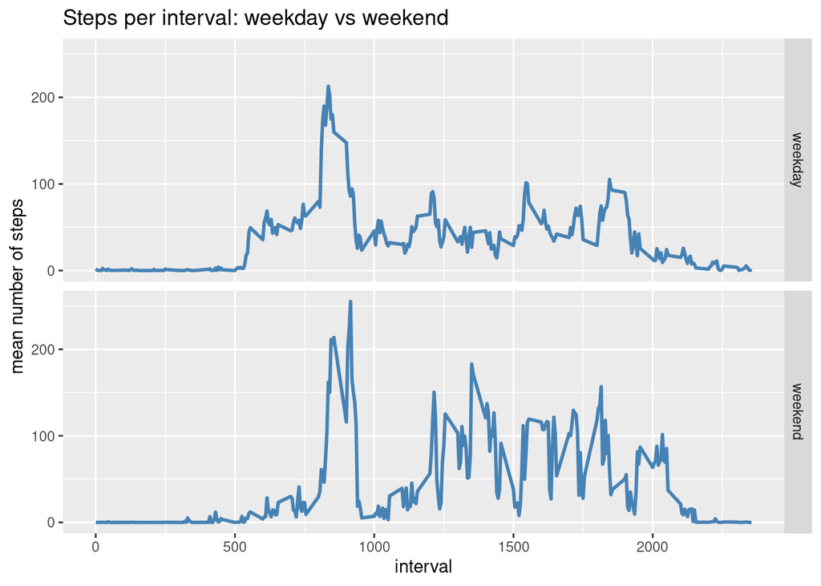

```r
ggplot(data = data_byintervalwkd, aes(x = interval, y = meansteps)) +
  geom_line(color = "steelblue", size = 1) +
  labs(title = "Steps per interval: weekday vs weekend",
       y = "mean number of steps", x = "interval") +
  facet_grid(day~.)
```